# Análisis del comportamiento suicida en el departamento del Tolima (2013 - 2021)

Cuaderno de análisis de datos

Author

Affiliation

Carolina Ortiz López, MsC

Universidad San Buenaventura

Published

Wednesday, December 11, 2024

Keywords

Suicidio, Políticas públicas de salud mental, Departamente del Tolima

# 1 Instalación y cargar de paquetes

```r
if (!require("brms")) install.packages("brms")
if (!require("dplyr")) install.packages("dplyr")
if (!require("ggalluvial")) install.packages("ggalluvial")
if (!require("ggplot2")) install.packages("ggplot2")
if (!require("glmmTMB")) install.packages("glmmTMB")
if (!require("here")) install.packages("here")
if (!require("htmlwidgets")) install.packages("htmlwidgets")
if (!require("leaflet")) install.packages("leaflet")
if (!require("performance")) install.packages("performance")
if (!require("readxl")) install.packages("readxl")
if (!require("tidyverse")) install.packages("tidyverse")
```

# 2 Cargar los datos

A continuación cargaremos los datos recopilados desde el archivo “Data/Cond_Suicida_2013_2021” que contiene información de marcadores de la Casos_Suicidio y Casos_Intento del departamento del Tolima para el periodo 2013 - 2021.

```r
data <- read_xlsx (here("Data/Cond_Suicida_2013_2021.xlsx"))
head(data)
```

```
# A tibble: 6 × 10
    No. Municipio    Casos_Suicidio Tasa_Mortalidad Suicidio_Hombres
  <dbl> <chr>                 <dbl>           <dbl>            <dbl>
1     1 Cajamarca                30            17.5            23.7
2     2 Alpujarra                 7            16.3             5.53
3     3 Santa Isabel              8            14.3             6.33
4     4 Rovira                   26            13.9            20.6
5     5 Icononzo                 14            13.8            11.1
6     6 Falan                    10            13.4             7.91
# ℹ 5 more variables: Suicidio_Mujeres <dbl>, Casos_Intento <dbl>,
#   Tasa_Incidencia <dbl>, Intento_Hombres <dbl>, Intento_Mujeres <dbl>
```

Vamos a analizar el comportamiento suicida en hombres y mujeres. En primero lugar, debemos reestructurar la tabla sustancialmente.

# 3 Reestrcturación de los datos:

Vamos a seleccionar las columnas relevantes y a generar una tabla larga para hombres y mujeres teneindo en cuanto los intesntos y los suicidios completados.

```r
library(tidyr)

# Reshape the data to long format for counts
data_long <- data %>%
  select(Municipio, Suicidio_Hombres, Suicidio_Mujeres, Intento_Hombres, Intento_Mujeres) %>%
  pivot_longer(
    cols = starts_with("Suicidio_"),
    names_to = "Sexo",
    names_prefix = "Suicidio_",
    values_to = "Completados"
  ) %>%
  left_join(
    data %>%
      select(Municipio, Intento_Hombres, Intento_Mujeres) %>%
      pivot_longer(
        cols = starts_with("Intento_"),
        names_to = "Sexo",
        names_prefix = "Intento_",
        values_to = "Intentos"
      ),
    by = c("Municipio", "Sexo")
  )

str(data_long)
```

```
tibble [94 × 6] (S3: tbl_df/tbl/data.frame)
 $ Municipio      : chr [1:94] "Cajamarca" "Cajamarca" "Alpujarra" "Alpujarra" ...
 $ Intento_Hombres: num [1:94] 76.69 76.69 6.25 6.25 18.34 ...
 $ Intento_Mujeres: num [1:94] 107.31 107.31 8.75 8.75 25.66 ...
 $ Sexo           : chr [1:94] "Hombres" "Mujeres" "Hombres" "Mujeres" ...
 $ Completados    : num [1:94] 23.72 6.28 5.53 1.47 6.33 ...
 $ Intentos       : num [1:94] 76.69 107.31 6.25 8.75 18.34 ...
```

Podemos apreciar que generamos nuevas columnas denominadas “Sexo”, “Completados” e “Intentos”. Con la tabla transformada podemos realizar el modelamiento estadístico. Dejaremos la visualización de los datos (gráficos) para después. Estamos intersados en modelar la distribución de los suicidios entre hombres y mujeres, condicionando en los intentos.

# 4 Modelamiento estadístico

## 4.1 Transformar los datos

Para modelar adecuadamente estas variables, los casos e intentos de suciidios deben ser intregres (numeros completos, no fracciones).

```r
data_long$Completados <- as.integer(data_long$Completados)
data_long$Intentos <- as.integer(data_long$Intentos)

str(data_long)
```

```
tibble [94 × 6] (S3: tbl_df/tbl/data.frame)
 $ Municipio      : chr [1:94] "Cajamarca" "Cajamarca" "Alpujarra" "Alpujarra" ...
 $ Intento_Hombres: num [1:94] 76.69 76.69 6.25 6.25 18.34 ...
 $ Intento_Mujeres: num [1:94] 107.31 107.31 8.75 8.75 25.66 ...
 $ Sexo           : chr [1:94] "Hombres" "Mujeres" "Hombres" "Mujeres" ...
 $ Completados    : int [1:94] 23 6 5 1 6 1 20 5 11 2 ...
 $ Intentos       : int [1:94] 76 107 6 8 18 25 57 81 21 29 ...
```

Podemos apreciar que “Completados” e “Intentos” son ahora integrers.

## 4.2 Ajuste del modelo

Para este caso ajustaremos un modelo binomial, donde los suicidios son los casos (completados, succed) de intentos de sucicidio. Utilizaremos una distribnucion binominal con una función link “logit” para estimar las probabilidades (log-odds) de que los intentos de suicidio terminen en suicidio en función del sexo. La regresión toma la siguiente notación:

$$\log\left(\frac{p}{1-p}\right) = \beta_0 + \beta_1 \times \text{Sexo}$$

Donde $P$ es la probabilidad de completar el suicidio dado un intento. $\beta_0$ es la probabilidad (log-oods) de completar el suicio para los hombres (la categoría de referencia); y $\beta_1$ representa el cambio de probabilidad (log-odds) de completar el suicidio para las mujeres en relación con los hombres.

```r
Suicidios_Mdl1 <- bf(Completados | trials(Intentos) ~ Sexo)

get_prior(Suicidios_Mdl1, data_long, family = binomial)
```

```
                prior     class        coef group resp dpar nlpar lb ub
               (flat)         b
               (flat)         b SexoMujeres
 student_t(3, 0, 2.5) Intercept
       source
      default
 (vectorized)
      default
```

```r
Suicidios_Fit1 <-
  brm(
    data = data_long,
    family = binomial,
    formula = Suicidios_Mdl1,
    chains = 4,
    cores = 4,
    warmup = 2500,
    iter = 5000,
    seed = 8807,
    control = list(adapt_delta = 0.99, max_treedepth = 15),
    file = here("Models/Suicidio_Completados_Fit1.rds"),
    file_refit = "never"
    )
```

## 4.3 Visualización de resultados

A continuación visualizamos la tabla de resultados:

```r
summary(Suicidios_Fit1)
```

```
 Family: binomial
  Links: mu = logit
Formula: Completados | trials(Intentos) ~ Sexo
   Data: data_long (Number of observations: 94)
  Draws: 4 chains, each with iter = 5000; warmup = 2500; thin = 1;
         total post-warmup draws = 10000

Regression Coefficients:
            Estimate Est.Error l-95% CI u-95% CI Rhat Bulk_ESS Tail_ESS
Intercept      -0.97      0.04    -1.05    -0.88 1.00     6511     5309
SexoMujeres    -2.03      0.09    -2.21    -1.86 1.00     3425     4357

Draws were sampled using sampling(NUTS). For each parameter, Bulk_ESS
and Tail_ESS are effective sample size measures, and Rhat is the potential
scale reduction factor on split chains (at convergence, Rhat = 1).
```

Dado que los hombres

$$\text{logit}(p_{\text{men}}) = -0.97$$
podemos calcular que la probabilidad de completar un suicidio es:

$$p_{\text{men}} = \frac{e^{-0.97}}{1 + e^{-0.97}} \approx \frac{0.379}{1 + 0.379} \approx 0.2747$$
Esto quiere decir que el 27.5% de los hombres en el departamento del tolima culminan sus intentos de suicidio

$$\text{logit}(p_{\text{women}}) = -0.97 + (-2.03) = -3.00$$
Lo que indica una probabilidad de

$$p_{\text{women}} = \frac{e^{-3.00}}{1 + e^{-3.00}} \approx \frac{0.0498}{1 + 0.0498} \approx 0.0474$$
Esto quiere decir que aproximadamente un 4% de las mujeres completan sus intentos de suicidio.

Ahora bien, si comparamos el odds ratio de las mujeres y hombres

$$\text{OR} = e^{-2.03} \approx 0.1315$$
obtenemos que las muejres tienen aproximadamente 0.13 veces probabilidad (odds) de completar el sucidio que los hombres. Alternativamente se puede decir que (1/0.1315 = 7.6) los hombre tienen una probabilidad 7.6 veces mayor de completar suicidios que las mujeres.

# 5 Visualización de los resultados

Ahora veremos gráficamente estas estimaciones utilizando conditional effects

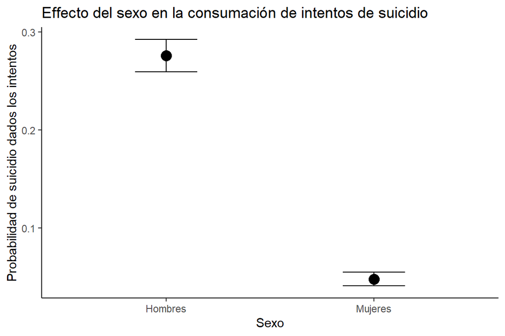

Figure 1: Effecto del sexo en la consumación de intentos de suicidio

```r
Suicidios_CE <- conditional_effects(Suicidios_Fit1)

Suicidios_CE_Fig <- plot(Suicidios_CE, plot = FALSE)[[1]]

Suicidios_CE_Fig <- Suicidios_CE_Fig +
  labs(title = "Effecto del sexo en la consumación de intentos de suicidio",
       y = "Probabilidad de suicidio dados los intentos",
       x = "Sexo")+
  theme_classic()


ggsave (Suicidios_CE_Fig ,
        file = here("Plots/Suicidio_Sexo.jpg"),
        width = 15,
        height = 10,
        units = "cm")


Suicidios_CE_Fig
```

# 6 Visualización por municipio

En esta sección tomaremos los resultados pare realizar una visualización pór municipio utilizando los paquetes “rnaturalearth” y “rnaturalearthdata”.

## 6.1 Instalar y cragar los paquetes

```r
if (!require("rnaturalearth")) install.packages("rnaturalearth")
if (!require("rnaturalearthdata")) install.packages("rnaturalearthdata")
if (!require("sf")) install.packages("sf")
if (!require("viridis")) install.packages("viridis")

if (!require("devtools")) install.packages("devtools")
library(devtools)
devtools::install_github("ropensci/rnaturalearthhires")
```

## 6.2 Crear coodenadas de los municipios

Ahora, adjuntamos las coordenadas de los municipios al data frame con el que hemos estado trabajando.

```r
# Creamos un data frame con las coordenadas de los municipios.
coordinates <- data.frame(
  Municipio = c("Cajamarca", "Alpujarra", "Santa Isabel", "Rovira", "Icononzo", "Falan",
                "Carmen de Apicalá", "Alvarado", "Murillo", "Villarrica", "San Antonio",
                "Palocabildo", "Roncesvalles", "Honda", "Herveo", "Mariquita", "Libano",
                "Melgar", "Cunday", "Fresno", "Venadillo", "Suárez", "Armero Guayabal",
                "Ambalema", "Ibagué", "Chaparral", "Espinal", "Lérida", "Coyaima", "Ataco",
                "Planadas", "Anzóategui", "Dolores", "Guamo", "Purificación", "Coello",
                "Ortega", "San Luis", "Rioblanco", "Natagaima", "Valle de San Juan", "Piedras",
                "Casabianca", "Villahermosa", "Saldaña", "Prado", "Flandes"),
  Latitude = c(4.4423, 3.417, 4.713, 4.239, 4.183, 5.083, 4.073, 4.567, 4.874, 3.933,
               3.920, 5.118, 4.016, 5.208, 5.084, 5.198, 4.921, 4.204, 4.061, 5.152,
               4.690, 4.047, 5.031, 4.782, 4.4389, 3.723, 4.150, 4.861, 3.833, 3.590,
               3.200, 4.630, 3.533, 4.030, 3.858, 4.283, 3.938, 5.203, 3.521, 3.622,
               4.288, 4.498, 5.081, 5.030, 3.930, 3.755, 4.289),
  Longitude = c(-75.4287, -74.917, -75.097, -75.247, -74.533, -74.960, -74.720, -74.950,
                -75.170, -74.600, -75.467, -75.029, -75.607, -74.735, -75.170, -74.891,
                -75.063, -74.640, -74.693, -75.035, -74.934, -74.831, -74.891, -74.764,
                -75.2322, -75.483, -74.880, -74.910, -75.083, -75.501, -75.643, -75.102,
                -74.733, -74.970, -74.933, -74.933, -75.220, -74.923, -75.463, -75.094,
                -75.114, -74.875, -75.124, -75.120, -75.020, -74.927, -74.817)
)

# Juntamos los das datasets
data_long <- left_join(data_long, coordinates, by = "Municipio")
```

## 6.3 Visualizar mapa del Tolima

Ahora utilizamos los paquetes de geolocalización para ver el mapa del departamento del Tolima con los municipios del del data frame.

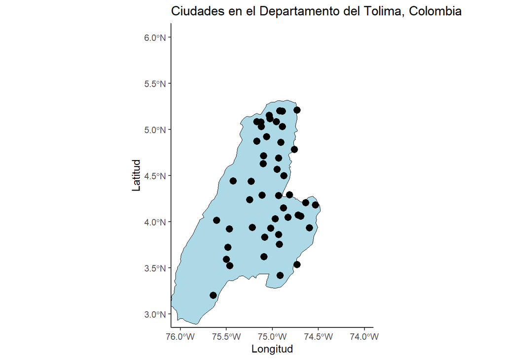

```r
library(ggplot2)
library(rnaturalearth)
library(rnaturalearthdata)
library(sf)
library(dplyr)
library(readxl)

# Descargamos los mapas de Colombia
colombia_map <- ne_countries(scale = "medium", country = "Colombia", returnclass = "sf")
col_departments <- ne_states(country = "Colombia", returnclass = "sf")

# Filtramos en la base de datos de mapas al departamento del tomila
tolima_map <- col_departments %>% filter(name == "Tolima")

# Creamos el mapa de las ciudades
ggplot(data = tolima_map) +
  geom_sf(fill = "lightblue", color = "black") +
  geom_point(data = data_long, aes(x = Longitude, y = Latitude), color = "black", size = 3) + # Plot cities
  labs(title = "Ciudades en el Departamento del Tolima, Colombia", x = "Longitud", y = "Latitud") +
  coord_sf(xlim = c(-76, -74), ylim = c(3, 6))  +
  theme_classic()
```

Ahora, verificamos que nuestros datos y el mapa del tolima usan las mismas coordenadas de referencia (CRS). Esto es crucial para las operaciones espaciales que relizaremos.

```r
st_crs(tolima_map)
```

```
Coordinate Reference System:
  User input: WGS 84
  wkt:
GEOGCRS["WGS 84",
    DATUM["World Geodetic System 1984",
        ELLIPSOID["WGS 84",6378137,298.257223563,
            LENGTHUNIT["metre",1]]],
    PRIMEM["Greenwich",0,
        ANGLEUNIT["degree",0.0174532925199433]],
    CS[ellipsoidal,2],
        AXIS["latitude",north,
            ORDER[1],
            ANGLEUNIT["degree",0.0174532925199433]],
        AXIS["longitude",east,
            ORDER[2],
            ANGLEUNIT["degree",0.0174532925199433]],
    ID["EPSG",4326]]
```

## 6.4 Convertir las coodenadas del dataset

Ahora, convertimos nuestrso datos en un objeto `sf`, especificando las coordenadas y el CRS.

```r
data_long_sf <- st_as_sf(
  data_long,
  coords = c("Longitude", "Latitude"),
  crs = 4326,  # Mantemos lel sistema de referencia WGS84
  remove = FALSE
)
```

Con el siguiente código, nos aseguramos que nuestros datos y el mapa tengan las mismas coordenadas:

```r
st_crs(data_long_sf)
```

```
Coordinate Reference System:
  User input: EPSG:4326
  wkt:
GEOGCRS["WGS 84",
    ENSEMBLE["World Geodetic System 1984 ensemble",
        MEMBER["World Geodetic System 1984 (Transit)"],
        MEMBER["World Geodetic System 1984 (G730)"],
        MEMBER["World Geodetic System 1984 (G873)"],
        MEMBER["World Geodetic System 1984 (G1150)"],
        MEMBER["World Geodetic System 1984 (G1674)"],
        MEMBER["World Geodetic System 1984 (G1762)"],
        MEMBER["World Geodetic System 1984 (G2139)"],
        ELLIPSOID["WGS 84",6378137,298.257223563,
            LENGTHUNIT["metre",1]],
        ENSEMBLEACCURACY[2.0]],
    PRIMEM["Greenwich",0,
        ANGLEUNIT["degree",0.0174532925199433]],
    CS[ellipsoidal,2],
        AXIS["geodetic latitude (Lat)",north,
            ORDER[1],
            ANGLEUNIT["degree",0.0174532925199433]],
        AXIS["geodetic longitude (Lon)",east,
            ORDER[2],
            ANGLEUNIT["degree",0.0174532925199433]],
    USAGE[
        SCOPE["Horizontal component of 3D system."],
        AREA["World."],
        BBOX[-90,-180,90,180]],
    ID["EPSG",4326]]
```

```r
# Si las coordenas son diferentes, se homogenizan
if (st_crs(data_long_sf) != st_crs(tolima_map)) {
  data_long_sf <- st_transform(data_long_sf, crs = st_crs(tolima_map))
}
```

## 6.5 Visualizar el número de suicidios e intentos

Ahora, utilizamos ggplot para visualizar el número de sucidios por municipio en el Departamento del Tolima.

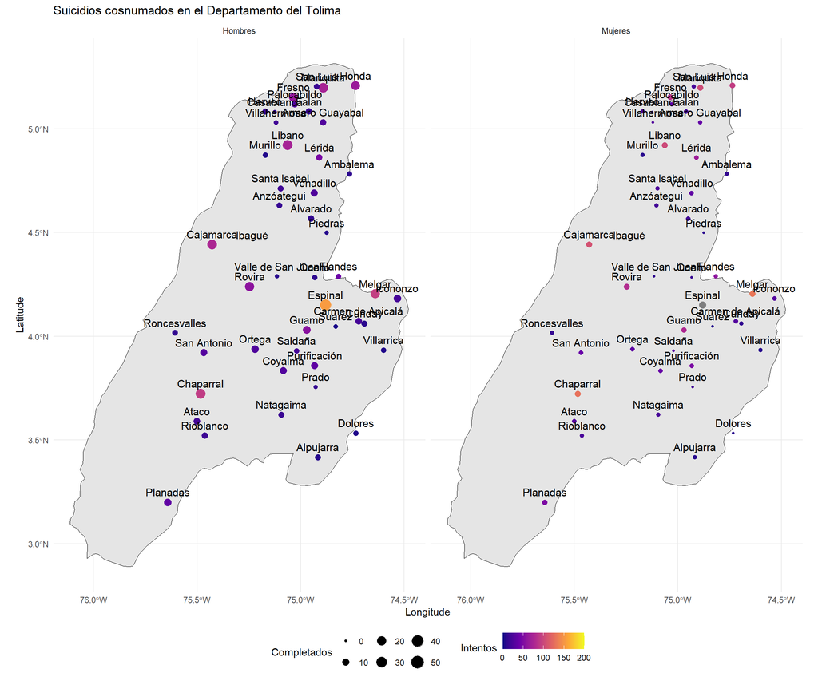

Figure 2: Suicidios de hombres y mujeres en el Departamento del Tolima

```r
# Creamos el mapa mase de Tolima
base_map <- ggplot() +
  geom_sf(data = tolima_map, fill = "gray90", color = "black")

# Adjuntamos puntos como probabilidades
Suicide_map <- base_map +
  geom_sf(
    data = data_long_sf,
    aes(geometry = geometry,
        color = Intentos,
        size = Completados),

  ) +
  scale_color_viridis_c(option = "plasma",
                        limits = c(0, 200)) +

  scale_size(limits = c(0, 50)) +

  theme_minimal() +
  theme(legend.position = "bottom") +

  labs(
    title = "Suicidios cosnumados en el Departamento del Tolima",
    color = "Intentos"
  ) +

    geom_text(
    data = data_long_sf,
    aes(x = Longitude, y = Latitude, label = Municipio),
    size = 4, color = "black", nudge_y = 0.05
  ) +

  facet_wrap(~ Sexo)

ggsave (Suicide_map,
        file = here("Plots/Suicidio_Ciudad.jpg"),
        width = 24,
        height = 20,
        units = "cm")

Suicide_map
```

Figure 2 nos muestra el numero de suicdios consumados con el tamaño de los puntos y los intentos con código de color.

## 6.6 Mapa interactivo

Podemos también utilizar el paquete `leaflet` para hacer un mapa interactivo. En primer lugar, creamos un mapa centrado en el departamento del Tolima.

```r
map <- leaflet() %>%
  addTiles() %>%  # Add default OpenStreetMap tiles
  setView(lng = mean(data_long_sf$Longitude), lat = mean(data_long_sf$Latitude), zoom = 8)
```

A continuación, utilizamos el mapa para gragar capas y visualizar la distribución de intentos y suicidios en canda uno de los municipios del departamento del Tolima.

```r
# Create color palette
pal <- colorNumeric(
  palette = "Plasma",
  domain = data_long_sf$Intentos
)

# Separate data by Sexo
data_hombres <- data_long_sf %>% filter(Sexo == "Hombres")
data_mujeres <- data_long_sf %>% filter(Sexo == "Mujeres")

# Adicionamos las capas
Suicidio_Mapa <- leaflet() %>%
  addTiles() %>%
  setView(lng = mean(data_long_sf$Longitude), lat = mean(data_long_sf$Latitude), zoom = 8) %>%
  addPolygons(
    data = tolima_map,
    fillColor = "transparent",
    color = "blue",
    weight = 2,
    opacity = 1,
    group = "Tolima Boundary"
  ) %>%
  addCircleMarkers(
    data = data_hombres,
    lng = ~Longitude,
    lat = ~Latitude,
    radius = ~sqrt(Completados) * 2,
    stroke = TRUE,
    fillOpacity = 0.7,
    popup = ~paste0(
      "<strong>Municipio: </strong>", Municipio, "<br>",
      "<strong>Sexo: </strong>", Sexo, "<br>",
      "<strong>Intentos: </strong>", Intentos, "<br>",
      "<strong>Completados: </strong>", Completados, "<br>"
    ),
    group = "Hombres"
  ) %>%
  addCircleMarkers(
    data = data_mujeres,
    lng = ~Longitude,
    lat = ~Latitude,
    radius = ~sqrt(Completados) * 2,
    stroke = TRUE,
    fillOpacity = 0.7,
    popup = ~paste0(
      "<strong>Municipio: </strong>", Municipio, "<br>",
      "<strong>Sexo: </strong>", Sexo, "<br>",
      "<strong>Intentos: </strong>", Intentos, "<br>",
      "<strong>Completados: </strong>", Completados, "<br>"
    ),
    group = "Mujeres"
  ) %>%
  addLayersControl(
    overlayGroups = c("Hombres", "Mujeres"),
    options = layersControlOptions(collapsed = FALSE)
  )

Suicidio_Mapa
```

[interactive chart not shown]

El mapa nos permite ver la información en canada municipio separado por hombres y mujeres.